# Particle Swarm Optimization

## Swarm intelligence

Swarm intelligence is a branch of artificial intelligence that studies the collective behavior and emergent properties of complex, self-organized, decentralized systems with social structure. Such systems consist of simple interacting agents organized in small societies (swarms). Although each agent has a very limited action space and there is no central control, the aggregated behavior of the whole swarm exhibits traits of intelligence, i.e., an ability to react to environmental changes and decision-making capacities.

The main inspiration behind the development of swarm intelligence stems directly from nature. Fish schools, bird flocks, ant colonies and animal herds, with their amazing self-organization capabilities and reactions, produce collective behaviors that cannot be described simply by aggregating the behavior of each team member.

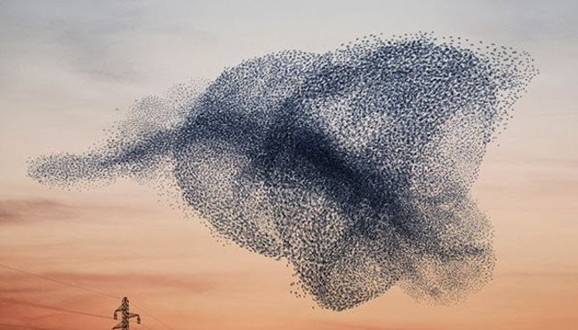

**Particle swarm optimization** was developed by Kennedy and Eberhart (1995) as a stochastic optimization algorithm based on social simulation models. The algorithm employs a population of search points that moves stochastically in the search space. Concurrently, the best position ever attained by each individual, also called its experience, is retained in memory. This experience is then **communicated to part or the whole population**, biasing its movement towards the most promising regions detected so far. The communication scheme is determined by a fixed or adaptive social network that plays a crucial role on the convergence properties of the algorithm.

The development of particle **swarm optimization was based on concepts** and rules that govern socially organized populations in nature, such as bird flocks, fish schools, and animal herds. Unlike the ant colony approach, where stigmergy is the main communication mechanism among individuals through their environment, in such systems communication is rather direct without altering the environment.

Intense research in systems where collective phenomena are met prepared the ground for the development of swarm intelligence. Notwithstanding their physical or structural differences, such systems share common properties, recognized as the five basic principles of swarm intelligence (Millonas, 1994):

1. **Proximity**: Ability to perform space and time computations.
2. **Quality**: Ability to respond to environmental quality factors.
3. **Diverse** response: Ability to produce a plurality of different responses.
4. **Stability**: Ability to retain robust behaviors under mild environmental changes.
5. **Adaptability**: Ability to change behavior when it is dictated by external factors.

```python
import random
import numpy as np
import pandas as pd
import matplotlib.pyplot as plt
```

## Fundamental Algorithm (canonical)

The early precursors of PSO were simulators of social behavior for visualizing bird flocks. Nearestneighbor velocity matching and acceleration by distance were the main rules employed to produce swarming behavior by simple agents in their search for food, in simulation experiments conducted by Russell C. Eberhart (Purdue School of Engineering and Technology, Indiana University Purdue University Indianapolis) and James Kennedy (Bureau of Labor Statistics, Washington, DC). After realizing the potential of these simulation models to perform optimization, Eberhart and Kennedy refined their model and published the first version of PSO in 1995.

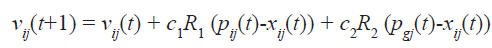

```python
#2d
class Particle():
    def __init__(self):
        self.position = np.array([(-1) ** (bool(random.getrandbits(1))) * random.random()*50, (-1)**(bool(random.getrandbits(1))) * random.random()*50])
        self.pbest_position = self.position
        self.pbest_value = float('inf')
        self.velocity = np.array([0,0])

    def __str__(self):
        print("My position is ", self.position, " and my pbest is ", self.pbest_position)

    def move(self):
        self.position = self.position + self.velocity
```

```python
#2D
class Space():

    def __init__(self, target, target_error, n_particles):
        self.target = target
        self.target_error = target_error
        self.n_particles = n_particles
        self.particles = []
        self.gbest_value = float('inf')
        self.gbest_position = np.array([random.random()*50, random.random()*50])

    def print_particles(self):
        for particle in self.particles:
            particle.__str__()

    def plot_particles(self):
        df = pd.DataFrame(columns=['x','y'])
        for particle in self.particles:
          df = df.append({'x': particle.position[0], 'y': particle.position[1]}, ignore_index=True)
        df.plot.scatter(x='x', y='y', c='DarkBlue')

    def fitness(self, particle):
        return particle.position[0] ** 2 + particle.position[1] ** 2 + target

    def set_pbest(self):
        for particle in self.particles:
            fitness_cadidate = self.fitness(particle)
            if(particle.pbest_value > fitness_cadidate):
                particle.pbest_value = fitness_cadidate
                particle.pbest_position = particle.position

    def set_gbest(self):
        for particle in self.particles:
            best_fitness_cadidate = self.fitness(particle)
            if(self.gbest_value > best_fitness_cadidate):
                self.gbest_value = best_fitness_cadidate
                self.gbest_position = particle.position

    def move_particles(self):
        for particle in self.particles:
            global W
            new_velocity = (W*particle.velocity) + (c1*random.random()) * (particle.pbest_position - particle.position) + \
                            (c2*random.random()) * (self.gbest_position - particle.position)
            particle.velocity = new_velocity
            particle.move()
```

```python
#3D
class Particle():
    def __init__(self):
        self.position = np.array([(-1) ** (bool(random.getrandbits(1))) * random.random()*50, (-1)**(bool(random.getrandbits(1))) * random.random()*50, (-1)**(bool(random.getrandbits(1))) * random.random()*50])
        self.pbest_position = self.position
        self.pbest_value = float('inf')
        self.velocity = np.array([0,0,0])

    def __str__(self):
        print("My position is ", self.position, " and my pbest is ", self.pbest_position)

    def move(self):
        self.position = self.position + self.velocity
```

```python
#3D
class Space():

    def __init__(self, target, target_error, n_particles):
        self.target = target
        self.target_error = target_error
        self.n_particles = n_particles
        self.particles = []
        self.gbest_value = float('inf')
        self.gbest_position = np.array([random.random()*50, random.random()*50, random.random()*50])

    def print_particles(self):
        for particle in self.particles:
            particle.__str__()

    def plot_particles(self):
        df = pd.DataFrame(columns=['x','y','z'])
        for particle in self.particles:
          df = df.append({'x': particle.position[0], 'y': particle.position[1], 'z': particle.position[2]}, ignore_index=True)

        fig = plt.figure()
        ax = fig.add_subplot(projection='3d')

        xs = np.array(df['x']).astype(int)
        ys = np.array(df['y']).astype(int)
        zs = np.array(df['z']).astype(int)
        ax.scatter(xs, ys, zs)

        plt.show()

    def fitness(self, particle):
        return particle.position[0] ** 2 + particle.position[1] ** 2 + target

    def set_pbest(self):
        for particle in self.particles:
            fitness_cadidate = self.fitness(particle)
            if(particle.pbest_value > fitness_cadidate):
                particle.pbest_value = fitness_cadidate
                particle.pbest_position = particle.position

    def set_gbest(self):
        for particle in self.particles:
            best_fitness_cadidate = self.fitness(particle)
            if(self.gbest_value > best_fitness_cadidate):
                self.gbest_value = best_fitness_cadidate
                self.gbest_position = particle.position

    def move_particles(self):
        for particle in self.particles:
            global W
            new_velocity = (W*particle.velocity) + (c1*random.random()) * (particle.pbest_position - particle.position) + \
                            (c2*random.random()) * (self.gbest_position - particle.position)
            particle.velocity = new_velocity
            particle.move()
```

### Pseudocode of the operation of PSO

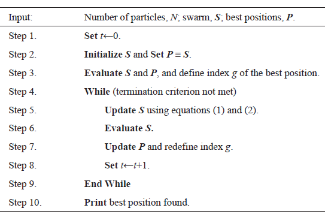

where t denotes the iteration counter; R1 and R2 are random variables uniformly distributed within [0,1]; and c1, c2, are weighting factors, also called the cognitive and social parameter, respectively. In the first version of PSO, a single weight, c = c1 = c2, called acceleration constant, was used instead of the two distinct weights in equation. However, the latter offered better control on the algorithm, leading to its predominance over the first version. At each iteration, after the update and evaluation of particles, best positions (memory) are also updated. Thus, the new best position of x at iteration t+1 is defined as follows:

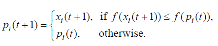

The new determination of index g for the updated best positions completes an iteration of PSO. The operation of PSO is provided in pseudocode in Table 1. Particles are usually initialized randomly, following a uniform distribution over the search space, A. This choice treats each region of A equivalently; therefore it is mostly preferable in cases where there is no information on the form of the search space or the objective function, requiring a different initialization scheme. Additionally, it is implemented fairly easily, as all modern computer systems can be equipped with a uniform random number generator.

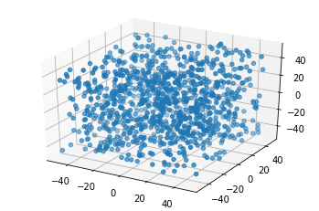

```python
W = 0.4 #0.9 e 0.4
c1 = 0.8
c2 = 0.9

target = 5
n_iterations = 100
target_error = 0.0001
n_particles = 1000

search_space = Space(target, target_error, n_particles)
particles_vector = [Particle() for _ in range(search_space.n_particles)]
search_space.particles = particles_vector
search_space.plot_particles()
```

```python
iteration = 0
while(iteration < n_iterations):
    search_space.set_pbest()
    search_space.set_gbest()

    if(abs(search_space.gbest_value - search_space.target) <= search_space.target_error):
        break

    search_space.move_particles()
    iteration += 1

print("The best solution is: ", search_space.gbest_position, " in n_iterations: ", iteration)
```

```
The best solution is:  [2.85255118e-03 8.93442932e-04 2.66095524e+01]  in n_iterations:  6
```

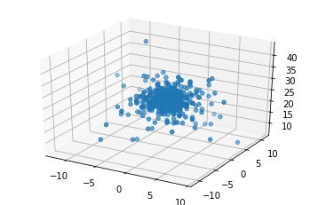

```python
search_space.plot_particles()
```

```python
search_space.print_particles()
```

[output not shown]

[output cut: 945 more lines]

```
My position is  [ 7.34366434e-01 -3.95471537e-03  2.56074385e+01]  and my pbest is  [ 7.34366434e-01 -3.95471537e-03  2.56074385e+01]
My position is  [ 1.82445033  0.1781764  24.97867973]  and my pbest is  [ 0.52908684  0.10944121 25.54998546]
My position is  [-1.86085919 -0.05393307 30.01492506]  and my pbest is  [ 1.2088375  -0.05832202 23.81435124]
My position is  [-0.2622002  -0.06801296 25.43502897]  and my pbest is  [-0.2622002  -0.06801296 25.43502897]
My position is  [ -2.0990469  -10.88215067  28.22937161]  and my pbest is  [-1.01315444 -2.83509846 23.83601236]
My position is  [ 0.576503   -0.36065199 26.47227522]  and my pbest is  [ 0.32495568 -0.13338278 26.66917654]
My position is  [-0.22903271 -0.77740482 26.76014864]  and my pbest is  [-0.07663432 -0.41140181 26.79802281]
My position is  [ 1.6192782  -0.11027014 23.91093945]  and my pbest is  [-0.9730285   0.81741705 28.17977224]
My position is  [-0.62593128  0.98074694 26.57396537]  and my pbest is  [-0.62593128  0.98074694 26.57396537]
My position is  [ 1.05367801  0.2321985  25.72882178]  and my pbest is  [ 0.97710656  0.29381867 25.80497361]
My position is  [-2.05654605  0.2159237  23.54498227]  and my pbest is  [-0.39342374  0.09529894 26.09342058]
My position is  [-0.68269467  0.23188755 25.74804564]  and my pbest is  [-0.68269467  0.23188755 25.74804564]
My position is  [-0.32276234  0.61216742 25.380504  ]  and my pbest is  [-2.96060038e-01 -1.20763224e-03  2.51195881e+01]
My position is  [ 1.7941209  -2.2546567  18.15283625]  and my pbest is  [ 1.7941209  -2.2546567  18.15283625]
My position is  [ 1.24481215  2.03215529 28.5905774 ]  and my pbest is  [ 1.24481215  2.03215529 28.5905774 ]
```